# DS105-07-05 - ANCOVA Activity in R.nb

# Load Libraries

```r
library("rcompanion")
library("car")
library("effects")
library("multcomp")
library("tidyverse")
library("dplyr")
```

# Load in Data

```r
cellPhone <- read.csv("./data/cellPhone.csv")

  # View data
    head(cellPhone)
```

|  | State | Account.Length | Area.Code | Phone | International.Plan | vMail.Plan | vMail.Message | Day.Mins | Day.Calls | Day.Charge | Eve.Mins | Eve.Calls | Eve.Charge | Night.Mins | Night.Calls | Night.Charge | International.Mins | International.Calls | International.Charge | CustServ.Calls | Churn |
| --- | --- | --- | --- | --- | --- | --- | --- | --- | --- | --- | --- | --- | --- | --- | --- | --- | --- | --- | --- | --- | --- |
| 1 | KS | 128 | 415 | 382-4657 | no | yes | 25 | 265.1 | 110 | 45.07 | 197.4 | 99 | 16.78 | 244.7 | 91 | 11.01 | 10.0 | 3 | 2.70 | 1 | 0 |
| 2 | OH | 107 | 415 | 371-7191 | no | yes | 26 | 161.6 | 123 | 27.47 | 195.5 | 103 | 16.62 | 254.4 | 103 | 11.45 | 13.7 | 3 | 3.70 | 1 | 0 |
| 3 | NJ | 137 | 415 | 358-1921 | no | no | 0 | 243.4 | 114 | 41.38 | 121.2 | 110 | 10.30 | 162.6 | 104 | 7.32 | 12.2 | 5 | 3.29 | 0 | 0 |
| 4 | OH | 84 | 408 | 375-9999 | yes | no | 0 | 299.4 | 71 | 50.90 | 61.9 | 88 | 5.26 | 196.9 | 89 | 8.86 | 6.6 | 7 | 1.78 | 2 | 0 |
| 5 | OK | 75 | 415 | 330-6626 | yes | no | 0 | 166.7 | 113 | 28.34 | 148.3 | 122 | 12.61 | 186.9 | 121 | 8.41 | 10.1 | 3 | 2.73 | 3 | 0 |
| 6 | AL | 118 | 510 | 391-8027 | yes | no | 0 | 223.4 | 98 | 37.98 | 220.6 | 101 | 18.75 | 203.9 | 118 | 9.18 | 6.3 | 6 | 1.70 | 0 | 0 |

# Question Setup

Many folks with international relatives often find themselves calling at odd hours to fit typical schedules in other time zones.

How does the presence or absence of an international phone plan (`International.Plan`) influence the use of nighttime minutes (`Night.Mins`), holding whether or not the client has a voicemail plan (`vMail.Plan`) constant?

# Data Wrangling

*NOTE: Ensure that all categorical variables are factors, not integers.*

Are there `null` values?

```r
colSums(is.na(cellPhone))
```

```
               State       Account.Length            Area.Code                Phone   International.Plan
                   0                    0                    0                    0                    0
          vMail.Plan        vMail.Message             Day.Mins            Day.Calls           Day.Charge
                   0                    0                    0                    0                    0
            Eve.Mins            Eve.Calls           Eve.Charge           Night.Mins          Night.Calls
                   0                    0                    0                    0                    0
        Night.Charge   International.Mins  International.Calls International.Charge       CustServ.Calls
                   0                    0                    0                    0                    0
               Churn
                   0
```

### Find the column names with `colnames()` function

```r
colnames(cellPhone)
```

```
 [1] "State"                "Account.Length"       "Area.Code"            "Phone"
 [5] "International.Plan"   "vMail.Plan"           "vMail.Message"        "Day.Mins"
 [9] "Day.Calls"            "Day.Charge"           "Eve.Mins"             "Eve.Calls"
[13] "Eve.Charge"           "Night.Mins"           "Night.Calls"          "Night.Charge"
[17] "International.Mins"   "International.Calls"  "International.Charge" "CustServ.Calls"
[21] "Churn"
```

### **Ensure the IV (Independent Variable) is a Factor**

For this question, the IV is `International.Plan` .

```r
str(cellPhone$International.Plan)
```

```
 chr [1:4617] " no" " no" " no" " yes" " yes" " yes" " no" " yes" " no" " yes" " no" " no" " no" " no" ...
```

This variable is an string, convert to a factor:

```r
cellPhone$International.Plan <- as.factor(cellPhone$International.Plan)

  # Confirm change to data type
    str(cellPhone$International.Plan)
```

```
 Factor w/ 2 levels " no"," yes": 1 1 1 2 2 2 1 2 1 2 ...
```

### **Ensure the CV (CoVariate) is a Factor**

Covariates can either be categorical or continuous.  
If you use a categorical CV, it needs to be formatted as factor data, not as an integer.

```r
str(cellPhone$vMail.Plan)
```

```
 chr [1:4617] " yes" " yes" " no" " no" " no" " no" " yes" " no" " no" " yes" " no" " no" " no" " no" ...
```

This variable is an string, convert to a factor:

```r
cellPhone$vMail.Plan <- as.factor(cellPhone$vMail.Plan)

  # Confirm change to data type
    str(cellPhone$vMail.Plan)
```

```
 Factor w/ 2 levels " no"," yes": 2 2 1 1 1 1 2 1 1 2 ...
```

# Testing Assumptions

- **Normality**
- **Homogeneity of Variance**
- **Homogeneity of Regression Slopes**
- **Sample Size**

### Normality

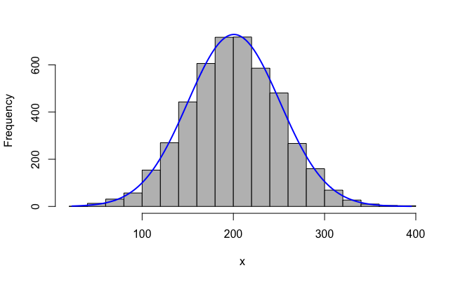

```r
plotNormalHistogram(cellPhone$Night.Mins)
```

### **Meets assumption: Normality**

Meets the assumption of normality, no need for transformation!

### **Homogeneity of Variance**

```r
leveneTest(Night.Mins~International.Plan, data=cellPhone)
```

```
Levene's Test for Homogeneity of Variance (center = median)
        Df F value Pr(>F)
group    1  0.8646 0.3525
      4615
```

### Meets assumption: **Homogeneity of Variance**

*`p`* **`> .05`** **—** **This test is not significant,** indicating that the data meets the assumption of homogeneity of variance.

### **Homogeneity of Regression Slopes**

Run a one-way ANOVA, with your covariate as the IV and the DV for your ANCOVA.  
If the *F* test is non-significant, the data meets the assumption of homogeneity of regression slopes.

```r
Homogeneity_RegrSlp = lm(Night.Mins~vMail.Plan, data=cellPhone)

anova(Homogeneity_RegrSlp)
```

```
Analysis of Variance Table

Response: Night.Mins
             Df   Sum Sq Mean Sq F value Pr(>F)
vMail.Plan    1      488  487.73  0.1909 0.6622
Residuals  4615 11791809 2555.10
```

### Meets assumption: Homogeneity of Regression Slopes

*`p`* **`> .05` — This test is not significant**, indicating that the data does meet the assumption of homogeneity of regression slopes.

### Sample Size

IVs or CVs: 2 ( `International.Plan`, `vMail.Plan` )

```r
str(cellPhone)
```

[output not shown]

### Meets assumption: Sample Size

Requirement: 20 samples per variable = 20 * 2 = 40 < **4617 observations present in data**.

# Running the Analysis

Run an ANCOVA using the same linear model format that you have used for regressions, but playing with the model terms some.

1. DV: `Night.Mins`
2. Covariate(s): `vMail.Plan`
3. Independent Variable: `International.Plan`

```r
ANCOVA = lm(Night.Mins~vMail.Plan + International.Plan*vMail.Plan, data=cellPhone)

anova(ANCOVA)
```

```
Analysis of Variance Table

Response: Night.Mins
                                Df   Sum Sq Mean Sq F value  Pr(>F)
vMail.Plan                       1      488   487.7  0.1909 0.66216
International.Plan               1     7979  7978.6  3.1235 0.07724 .
vMail.Plan:International.Plan    1      435   435.0  0.1703 0.67989
Residuals                     4613 11783396  2554.4
---
Signif. codes:  0 ‘***’ 0.001 ‘**’ 0.01 ‘*’ 0.05 ‘.’ 0.1 ‘ ’ 1
```

### Analysis:

- **`vMail.Plan`** does NOT have a significant effect ( *p* > .05 ) on **`Night.Mins`**
- **`International.Plan`** does NOT have a significant effect ( *p* > .05 ) on **`Night.Mins`**
- **`International.Plan`** and **`vMail.Plan`** combined do NOT have a significant effect ( P > .05) on **`Night.Mins`**

# Determine Means and Draw Conclusions

```r
adjMeans <- effect("International.Plan", ANCOVA)
```

```
NOTE: International.Plan is not a high-order term in the model
```

```r
adjMeans
```

```
 International.Plan effect
International.Plan
      no      yes
201.0535 196.5774
```

# Conclusion:

**An international cell phone plan does NOT result in increase night minutes usage**, regardless of whether the customer also has a voice mail plan.